# Casus 1 Data Engineer Macro-economie

Kasper Hermanns

2026-03-01

### Laden van benodigde packages

```r
library(tidyverse)
library(cbsodataR)
rm(list=ls()) # Verwijder alles uit de huidige environment
```

## Casus 1 Data Engineer Macro-economie

### In deze casus werk ik met de cijfers over de consumentenprijsindex (CPI).

De CPI cijfers zijn in te zien op Statline: https://opendata.cbs.nl/#/CBS/nl/dataset/83131NED/table?ts=1713952795072

Tabelbeschrijving:

Deze tabel bevat cijfers over het prijsverloop van een pakket goederen en diensten dat een gemiddeld Nederlands huishouden aanschaft. Dit wordt de consumentenprijsindex (CPI) genoemd. In de tabel staat ook de afgeleide consumentenprijsindex: dit is de CPI waarin het effect van veranderingen in de tarieven van productgebonden belastingen (bijvoorbeeld btw en accijns op alcohol en tabak) en subsidies en van consumptiegebonden belastingen (bijvoorbeeld motorrijtuigenbelasting) is verwijderd.

Daarnaast laat de tabel de maandmutatie en de jaarmutatie van de CPI zien. De jaarmutatie van de totale bestedingen staat bekend als de inflatie. De cijfers zijn in 2025 over 338 productgroepen te bekijken. Verder staan er 34 samentellingen van productgroepen (speciale aggregaten) in de tabel. Van elke productgroep is tevens te vinden hoeveel de Nederlandse consument er aan uitgeeft in verhouding tot zijn totale uitgaven. Dit noemen we de wegingscoëfficiënt. De totale weging is 100.000.

Cijfers van de CPI worden elke maand gepubliceerd. Daarnaast wordt aan het einde van het jaar een jaarcijfer bekendgemaakt. De CPI van een kalenderjaar wordt berekend als het gemiddelde van de indexcijfers van de twaalf maanden van dat jaar.

### Laden van de data

```r
# Het ID van deze tabel is 83131NED, deze wordt gebruikt als variabele om de data en metadata in te laden
table_id <- "83131NED"

data <- cbs_get_data(table_id)
data <- cbs_add_date_column(data)
metadata <- cbs_get_meta(table_id)
head(data,20)
```

```
## # A tibble: 20 × 11
##    Bestedingscategorieen Perioden Perioden_Date Perioden_freq CPI_1
##    <chr>                 <chr>    <date>        <fct>         <dbl>
##  1 "T001112  "           1996MM01 1996-01-01    M              68.0
##  2 "T001112  "           1996MM02 1996-02-01    M              68.3
##  3 "T001112  "           1996MM03 1996-03-01    M              68.9
##  4 "T001112  "           1996MM04 1996-04-01    M              69.1
##  5 "T001112  "           1996MM05 1996-05-01    M              69.0
##  6 "T001112  "           1996MM06 1996-06-01    M              68.7
##  7 "T001112  "           1996MM07 1996-07-01    M              68.8
##  8 "T001112  "           1996MM08 1996-08-01    M              68.8
##  9 "T001112  "           1996MM09 1996-09-01    M              69.4
## 10 "T001112  "           1996MM10 1996-10-01    M              69.5
## 11 "T001112  "           1996MM11 1996-11-01    M              69.4
## 12 "T001112  "           1996MM12 1996-12-01    M              69.4
## 13 "T001112  "           1996JJ00 1996-01-01    Y              68.9
## 14 "T001112  "           1997MM01 1997-01-01    M              69.4
## 15 "T001112  "           1997MM02 1997-02-01    M              69.6
## 16 "T001112  "           1997MM03 1997-03-01    M              70.1
## 17 "T001112  "           1997MM04 1997-04-01    M              70.2
## 18 "T001112  "           1997MM05 1997-05-01    M              70.4
## 19 "T001112  "           1997MM06 1997-06-01    M              70.0
## 20 "T001112  "           1997MM07 1997-07-01    M              70.2
## # ℹ 6 more variables: CPIAfgeleid_2 <dbl>, MaandmutatieCPI_3 <dbl>,
## #   MaandmutatieCPIAfgeleid_4 <dbl>, JaarmutatieCPI_5 <dbl>,
## #   JaarmutatieCPIAfgeleid_6 <dbl>, Wegingscoefficient_7 <int>
```

## Input parameters

We willen kwartaalcijfers met kwartaalmutaties genereren voor producten over een bepaalde verslagperiode. Dit sturen we d.m.v. deze input parameters:

- product_keys; codes van de ‘Bestedingscategorieen’
- period_begin; begin van de verslagperiode
- period_end; einde van de verslagperiode

## Functies

```r
# Deze functie zet maandelijkse CPI-gegevens om in kwartaal CPI-gegevens.
# De kwartaal CPI-gegevens worden berekend door het gemiddelde te nemen van de CPI van de drie onderliggende maanden.
m_to_q_CPI_data <- function(dataset){


  # Dit filtert de gegevens tot alleen de maandelijkse gegevens. Als er geen maandelijkse gegevens zijn, dan resulteert deze functie in een lege dataset.
  m_dataset <- dataset %>%
    filter(str_detect(Perioden,"MM"))

  # Hier pakken we elke 3e perioden_date om die vn de kwartalen te krijgen
  m_period_dates <- m_dataset$Perioden_Date
  q_period_dates <- m_period_dates[seq(1,length(m_period_dates),3)]

  q_dataset <- m_dataset %>%
    # We gaan nu de perioden codes van de maanden veranderen in hun respectievelijke kwartaalcodes. We maken hervoor gebruik van de consistentie van de codes voor perioden in het CBS, die zijn namelijk gestructureerd als yyyyXXww:
    # - yyyy is het jaartal (e.g. 2018)
    # - XX is de type periode, zoals jaar (JJ), maand (MM) of kwartaal (KW)
    # - ww is het index, bij jaren is dit altijd 00, maar bij maand en kwartaal geeft dit aan welke dit is (e.g. MM04 voor April, KW03 voor het 3e kwartaal)
    # Een periode code van 1997MM08 staat dus voor Augustus 1997, deze is dan weer om te zetten naar de kwartaal code door ceiling(ww/3) te gebruiken. In dit geval dus ceiling(8/3) = 3 voor de code 1997KW03
    mutate(Perioden = paste0(substr(Perioden, 1, 4),"KW","0",ceiling(as.integer(substr(Perioden, 7, 8))/3))) %>%

    # Groupeer de periodes, om de 3 maanden tot 1 gemiddelde te krijgen.
    # Bewaart ook de Bestedingscategorie en Wegingscoefficient
    group_by(Bestedingscategorieen,Perioden,Wegingscoefficient_7) %>%
    summarise(CPI_1 = mean(CPI_1, na.rm = TRUE),
              CPIAfgeleid_2 = mean(CPIAfgeleid_2, na.rm = TRUE),
              .groups = "drop")

  # Nu voegen we de kwartalen Perioden_Date waardes toe
  q_dataset$Perioden_Date <- q_period_dates

  return(q_dataset)
}

# Deze functie berekent de mutaties voor de opgegeven gegevens op basis van de lag_t. lag_t is standaard ingesteld op 1, wat betekent dat dit de mutatie van de gegevens berekent op basis van het vorige tijdstip.
# Als de data maanden of kwartalen gebruikt, dan berekent deze functie dus de respectievelijk maand of kwartaal mutaties.
calc_mutations <- function(data, lag_t = 1){
  return (round((data - lag(data,lag_t)) / lag(data,lag_t) * 100,1))
}

# Deze functie combineert de andere functies om de volledige maandelijkse CPI-dataset om te zetten in een gelijkwaardige kwartaal CPI-dataset.
get_quarterly_CPI <- function(dataset){

  q_data <- m_to_q_CPI_data(dataset)

  q_data$KwartaalmutatieCPI_3 <- calc_mutations(q_data$CPI_1)
  q_data$KwartaalmutatieCPIAfgeleid_4 <- calc_mutations(q_data$CPIAfgeleid_2)
  q_data$JaarmutatieCPI_5 <- calc_mutations(q_data$CPI_1,lag_t=4)
  q_data$JaarmutatieCPIAfgeleid_6 <- calc_mutations(q_data$CPIAfgeleid_2,lag_t=4)

  return(q_data)

}


# Nu kunnen we deze functies gebruiken om de totale CPI dataset om te zetten naar kwartaaldata. Deze dataset heeft dus alle Bestedingscategorieen en Perioden van de originele dataset.
kwartaal_CPI <- get_quarterly_CPI(data)
```

## Resultaten

Aangezien de complete dataset hierboven omgezet is naar kwartaalcijfers, kunnen we nu de resultaten per product en verslagperiode verkrijgen door in deze dataset te filteren.

```r
# Deze functie filtert de data op basis van de gegeven producten en verslagperiode
filter_data <- function(dataset, keys, period_1, period_2){

  dataset <- dataset %>%
    filter(Bestedingscategorieen %in% keys,
        Perioden_Date >= period_1,
        Perioden_Date <= period_2)

  return(dataset)
}

# Nu kunnen we de statistiek filteren
resultaten_KW_CPI <- filter_data(kwartaal_CPI,product_keys,period_start,period_end)

# De titels van de Bestedingscategorie wordt hier via de metadata aan de desbetreffende categoreen toegevoegd. Dit zorgt voor wat duidelijkere grafieken
titles_products <- metadata$Bestedingscategorieen %>% filter(Key %in% product_keys) %>% select(Key,Title)

resultaten_KW_CPI <- resultaten_KW_CPI %>%
  left_join(titles_products, by = join_by(Bestedingscategorieen == Key))
```

## Plotten van de resultaten

### De kwartaalmutaties van de 3 prducten naast elkaar

Hier worden de resultaten geplot langs elkaar, zo kun je goed het verschil zien tussen de producten. Wat meteen opvalt zijn de ontzettend grote mutaties van de gasprijs. Deze zijn te zien van 2022-2023 en komen overeen met de gascrisis door de start van de oorlog in Oekraine en de daaropvolgende normalisering van de prijzen.

De huurprijzen grafiek is ook interessant, aangezien deze alleen positieve kwartaalmutaties heeft en maar 1 kwartaal per jaar uberhaupt een mutatie heeft. Dit is natuurlijk in de lijn der verwachting gezien de wetten hieromheen.

De mutaties voor Gas en Fruit lijken op eerste ogenblik inderdaad sterk gecorreleerd te zijn met seizoen, aangezien deze heftig van positief naar negatief schommelt van het ene naar het andere kwartaal.

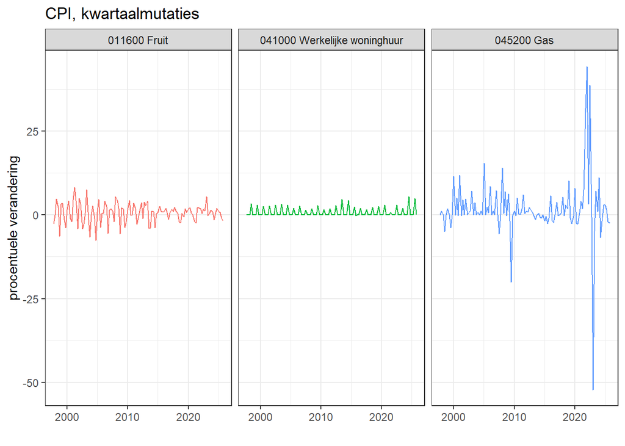

```r
plot_all3 <- ggplot(resultaten_KW_CPI, aes(x=Perioden_Date,
                          y=KwartaalmutatieCPI_3,
                          colour = Title)) +
  geom_line(show.legend = FALSE) +
  facet_wrap(Title ~ .) +
  labs(title = "CPI, kwartaalmutaties", x = "",
       y = "procentuele verandering")

plot_all3 +
  theme_bw()
```

### Plot Gas CPI vs Afgeleid CPI

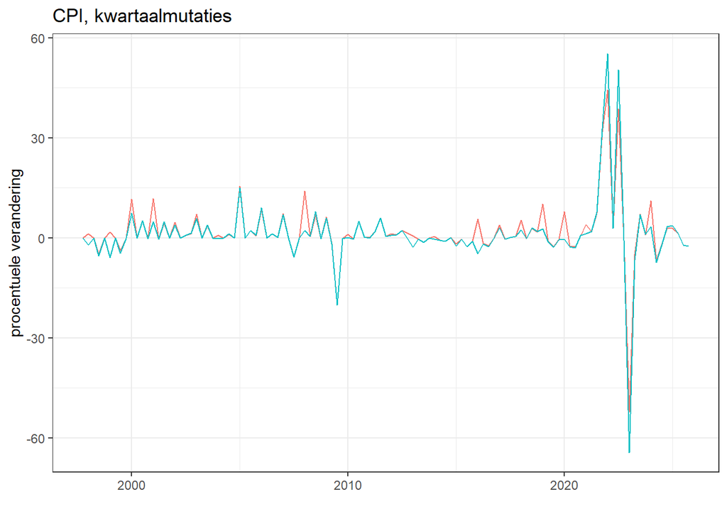

```r
gas_KW_CPI <- resultaten_KW_CPI %>%
  filter(Bestedingscategorieen == "CPI045200") %>%
  pivot_longer(cols=c(KwartaalmutatieCPI_3,KwartaalmutatieCPIAfgeleid_4))

plot_gas_CPI <- ggplot(gas_KW_CPI, aes(x=Perioden_Date,
                          y=value,
                          colour = name)) +
  geom_line(show.legend = FALSE) +
  labs(title = "CPI, kwartaalmutaties", x = "",
       y = "procentuele verandering")

plot_gas_CPI +
  theme_bw()
```

## Resultaten opslaan in database

```r
library(DBI)
library(RSQLite)

# Open connectie met een lokale SQL database
db <-dbConnect(SQLite(),"database.sqlite")
dbWriteTable(db, "resultaten_KW_CPI", resultaten_KW_CPI, overwrite = TRUE)

# Test of het goed is gegaan:
dbListTables(db)
```

```
## [1] "resultaten_KW_CPI"
```

```r
dbGetQuery(db, "SELECT * FROM resultaten_KW_CPI")
```

```
##     Bestedingscategorieen Perioden Wegingscoefficient_7     CPI_1 CPIAfgeleid_2
## 1               CPI011600 1997KW04                  986  71.41667      71.41667
## 2               CPI011600 1998KW01                  986  71.31667      71.31667
## 3               CPI011600 1998KW02                  986  74.63667      74.63667
## 4               CPI011600 1998KW03                  986  76.33667      76.33667
## 5               CPI011600 1998KW04                  986  71.54667      71.54667
## 6               CPI011600 1999KW01                  986  73.83000      73.83000
## 7               CPI011600 1999KW02                  986  76.44667      76.44667
## 8               CPI011600 1999KW03                  986  75.28667      75.28667
## 9               CPI011600 1999KW04                  986  72.35000      72.35000
## 10              CPI011600 2000KW01                  877  73.48333      73.48333
## 11              CPI011600 2000KW02                  877  76.59667      76.59667
## 12              CPI011600 2000KW03                  877  75.73667      75.73667
## 13              CPI011600 2000KW04                  877  74.18667      74.18667
## 14              CPI011600 2001KW01                  877  77.53333      77.53333
```

[output cut: 1005 more lines]

```r
dbGetQuery(db, "SELECT DISTINCT Title FROM resultaten_KW_CPI")
```

```
##                          Title
## 1                 011600 Fruit
## 2 041000 Werkelijke woninghuur
## 3                   045200 Gas
```

```r
dbGetQuery(db, "SELECT Perioden,KwartaalmutatieCPI_3,Title FROM resultaten_KW_CPI WHERE KwartaalmutatieCPI_3 > 25 OR KwartaalmutatieCPI_3 < -25")
```

```
##   Perioden KwartaalmutatieCPI_3      Title
## 1 2021KW04                 31.8 045200 Gas
## 2 2022KW01                 44.3 045200 Gas
## 3 2022KW03                 38.7 045200 Gas
## 4 2023KW01                -52.2 045200 Gas
```

```r
# Sluit connectie
dbDisconnect(db)
```